# Repertoire analysis

Clonal abundance, diversity and V-family gene usage

February 11, 2022

# Bcellmagic analysis pipeline

# Clonal abundance

To correct for the different number of sequences in each of the samples, the Bootstrapping technique was employed, in which 200 random bootstrap samples were taken, with size the number of sequences in the sample with less sequences (N). The solid line shows the mean Abundance of the bootstrap samples, whereas the transparent area shows the full Abundance range of the bootstrap samples.

All clonal abundance plots and tables with abundance values can be found under `repertoire_analysis/Abundance`.

## Clonal abundance per subject

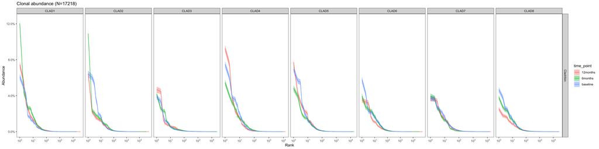

# Clonal diversity

The clonal diversity $D$ of the repertoire was calculated according to the general formula of Hill Diversity numbers:

$$\begin{aligned}
^{q}D = \left( \sum_{i=1}^Rp_i^q \right)^{1/(1-q)}
\end{aligned}$$

where:

- $p_i$ is the proportion of unique sequences belonging to clone $i$.
- $q$ are the values of the different diversity numbers.
- $R$ is the Richness, the number of different clones in the sample.

At $q=1$ the function is undefined and the limit to zero equals the exponential of the Shannon Entropy:

$$\begin{aligned}
^{1}D = exp \left( \sum_{i=1}^Rp_i ln(p_i) \right)
\end{aligned}$$

The intuition about the different Hill Diversity values is the following:

- At $q=0$ the diversity index equals the number of clones in the sample.
- At $q=1$ the diversity index is the geometric mean of the clones in the sample, weighted by their proportion in the sample.
- At $q>1$ more weight is given to the clones with higher proportions in the sample.

All clonal diversity plots and tables with diversity values can be found under `repertoire_analysis/Diversity`. To correct for the different number of sequences in each of the samples, the Bootstrapping technique was employed, in which 200 random bootstrap samples were taken, with size the number of sequences in the sample with less sequences (N). The solid line shows the mean Diversity of the bootstrap samples, whereas the transparent area shows the full Diversity range of the bootstrap samples.

## Clonal diversity per subject

### Clonal diversity at specific q values

#### q=1

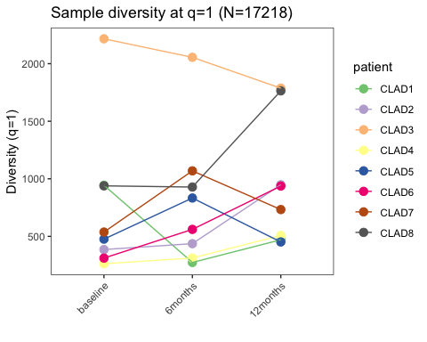

#### q=0

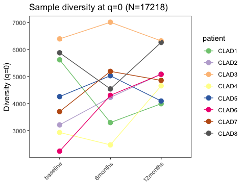